**Выполнила:** Ляпина Екатерина

Для создания собственной торговой стратегии, мною были выбраны акции компании ORACLE с биржи высокотехнологических компаний NASDAQ. Для анализа были взяты следующие данные. таймфрейм - 10 лет: http://www.nasdaq.com/symbol/orcl/historical

[figure not shown]

**Объектом исследования** является финансовое состояние корпорации ORACLE, выраженное в биржевых котировках.

**Предметом исследования** выступают экономические показатели, формирующиеся в результате деятельности фирмы.

**Цель работы:**

Установление структурных связей и закономерностей между элементами исследуемой системы в выбранной предметной области. Последующая интерпретация имеющихся данных, анализ применимости полученных результатов и создание наилучшей модели для дальнейшего прогнозирования подобных данных. В практическом смысле, аналитические модели могут успешно использоваться для решения задач выявления банкротства фирмы, и предупреждения подобных ситуаций.

**Задачи:**

Прохождение этапов извлечения, очистки и трансформации сырых данных. Анализ временных рядов в форме биржевых сводок. Применение техник для анализа временных рядов, анализ эффективности существующих торговых стратегий и создание своей собственной.

# Описание данных:

В нашем наборе данных 2517 наблюдений и 6 переменных. Исходный файл с данными в формате csv.

### Описание исходных переменных:

- **date**: дата котировки, интервал записей - день, период - 10 лет.
- **close** : цена на момент закрытия торгов.
- **volume** : количество акций, которые обращались на бирже в день записи, оьъем торгов.
- **open** : цена на момент открытия торгов.
- **high** : самая высокая цены за акцию за день.
- **low** : самая низкая цены за акцию за день.

Описательная статистика по нашей выбоке:

|  | date | close | volume | open | high | low |
| --- | --- | --- | --- | --- | --- | --- |
|  | Min. :2005-04-05 | Min. :11.52 | Min. : 6451964 | Min. :11.53 | Min. :11.68 | Min. :11.25 |
|  | 1st Qu.:2007-10-03 | 1st Qu.:18.80 | 1st Qu.: 20712120 | 1st Qu.:18.77 | 1st Qu.:18.99 | 1st Qu.:18.52 |
|  | Median :2010-04-05 | Median :23.70 | Median : 28215870 | Median :23.80 | Median :23.94 | Median :23.40 |
|  | Mean :2010-04-02 | Mean :25.57 | Mean : 31405684 | Mean :25.55 | Mean :25.83 | Mean :25.28 |
|  | 3rd Qu.:2012-09-28 | 3rd Qu.:32.38 | 3rd Qu.: 37413590 | 3rd Qu.:32.40 | 3rd Qu.:32.71 | 3rd Qu.:32.13 |
|  | Max. :2015-04-02 | Max. :46.23 | Max. :203555500 | Max. :46.36 | Max. :46.70 | Max. :46.15 |

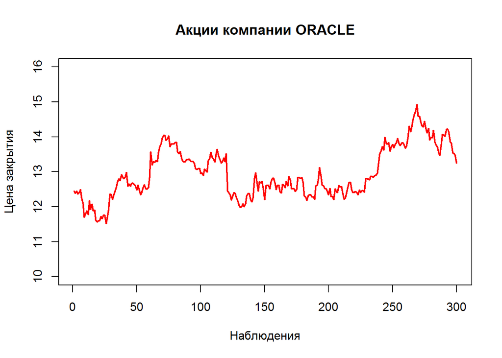

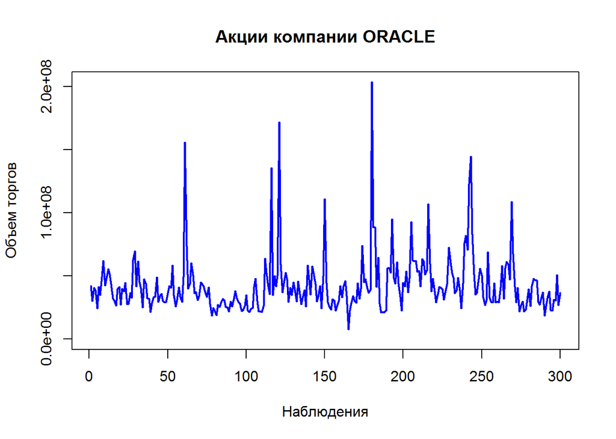

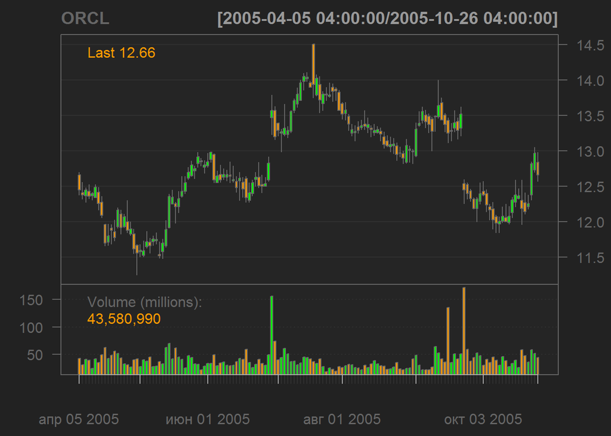

Столбиковый график:

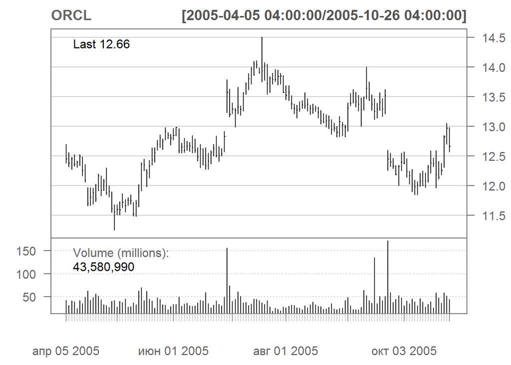

Скользящее среднее на основании цены закрытия, окно усреднения - 10 отсчетов:

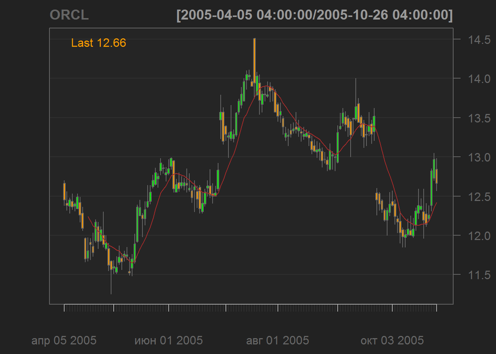

Скользящее среднее на основании цены закрытия, окно усреднения - 50 отсчетов:

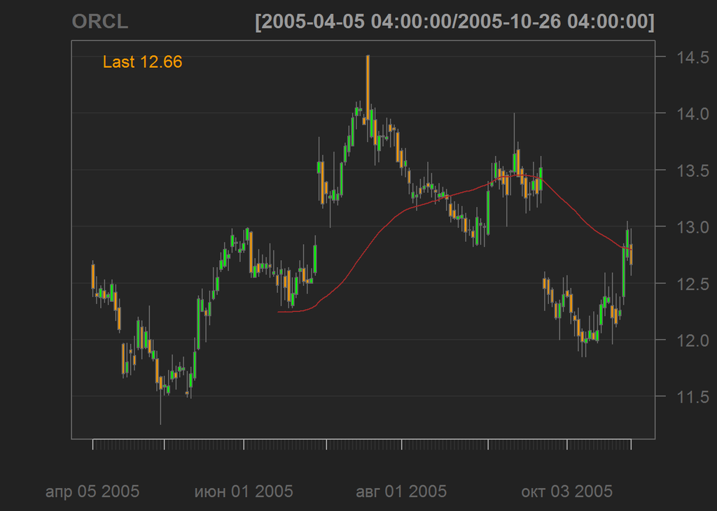

График сопоставления скользящих средних между собой:

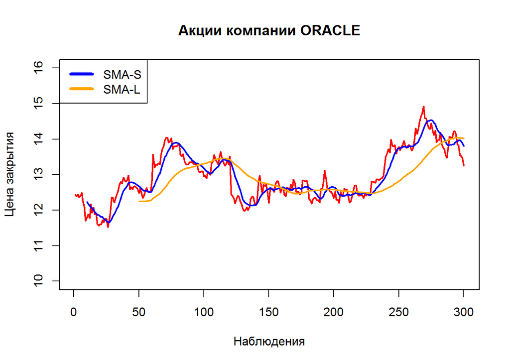

График сопоставления экспоненциальных скользящих средних между собой:

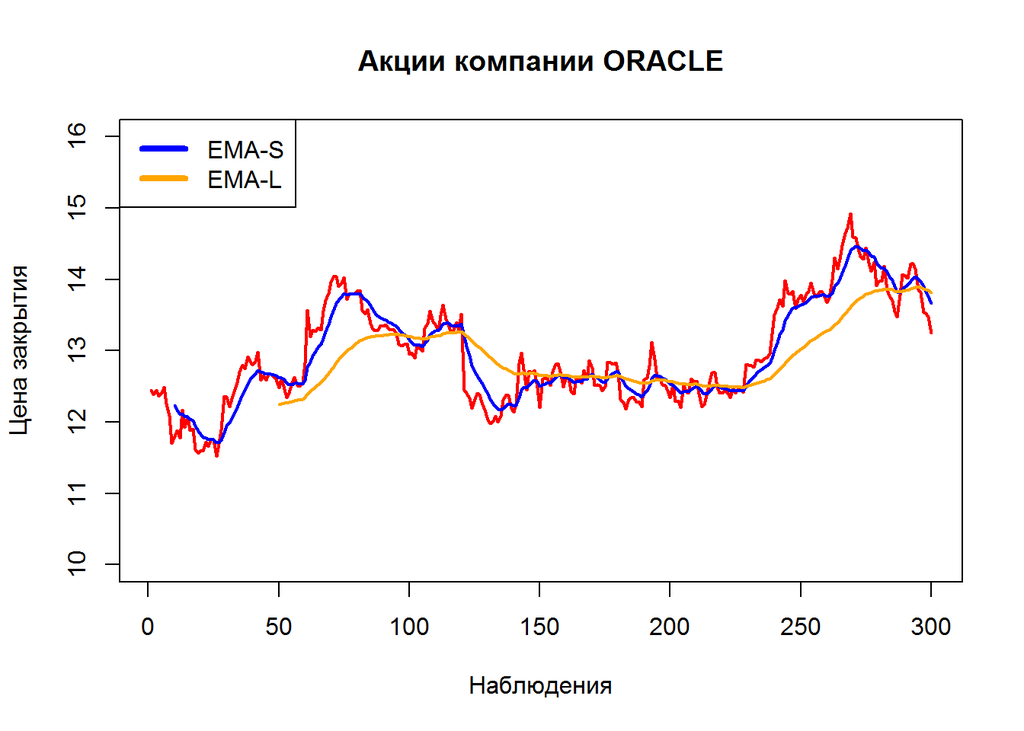

График сопоставления окон усреднения:

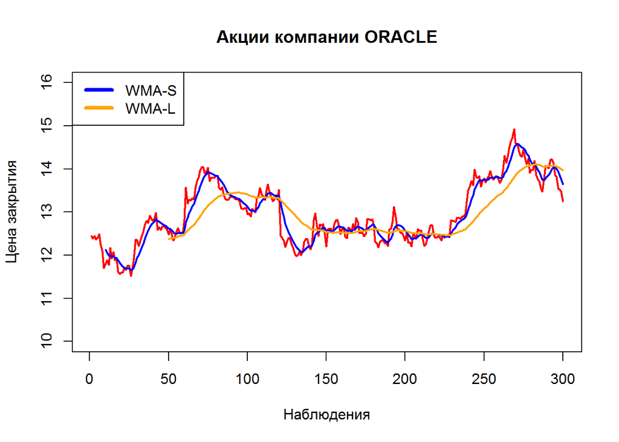

Графики для сопоставления короткого окна усреднения, для наглядности мы возьмем первые 100 наблюдений:

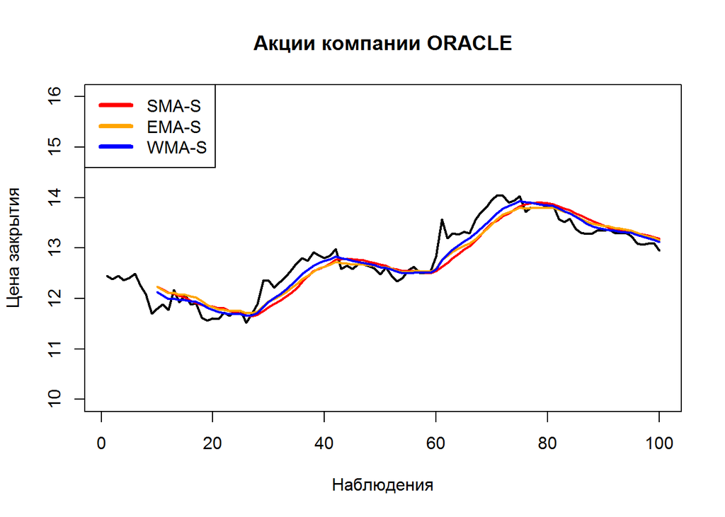

Графики для длинного окна усреднения, для наглядности мы возьмем первые 100 наблюдений:

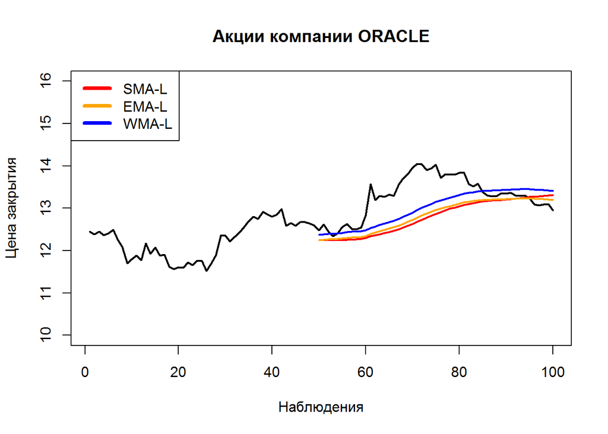

Для своего анализа я выбрала EMA-S и EMA-L, так как они более чувствительны к недавним значения. На графике розовый фон имеют интервалы времени, в течение которых значения “медленной” скользящей средней (EMA-L) превышают значения “быстрой” скользящей средней (EMA-S). Зеленый фон имеет обратная ситуация.

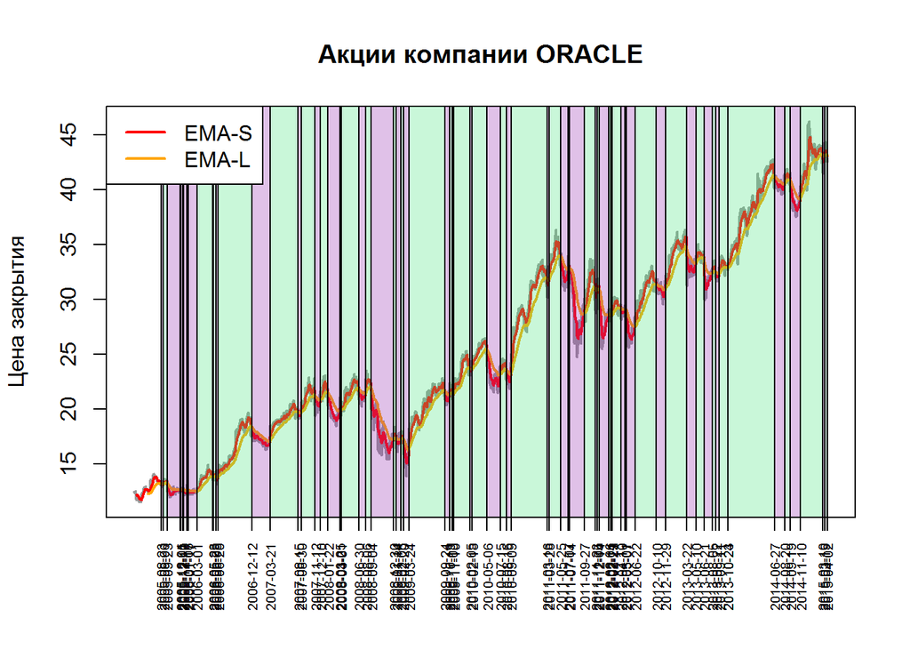

Попробуем добиться лучшего финансового результата, варьируя длительность окна усреднения. Пусть короткое окно усреднения будет от 5 до 10 счетов, а большое от 20 до 50 счетов. Определим лучшие варианты развития событий для всего интервала времени:

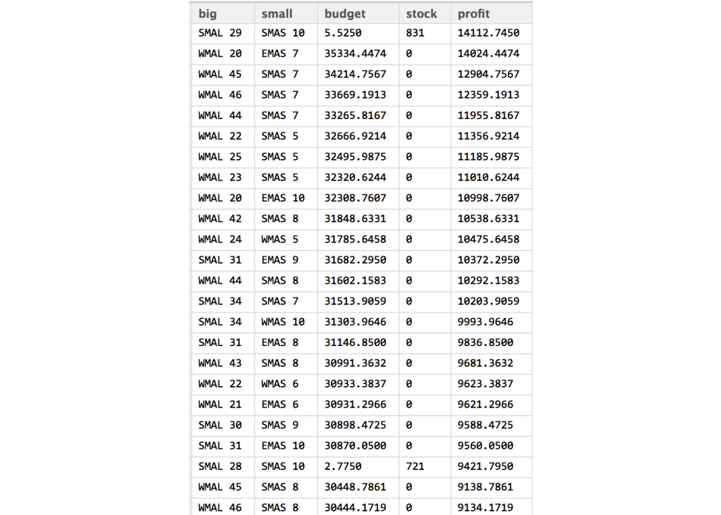

Используем самую выгодную стратегию: комбинацию SMA-S с окном усреднения 10 и SMA-L с окном усреднения 29. Добавим ряд условий (также продолжаем торговать на всю сумму, хотя это и не самое лучшее решение):

- Допускается возможность севершения сделки “с плечом” (1:2), то есть у нас будет в 2 раза больше средств на совершение каждой сделки
- Допускается возможность совершения “коротких” сделок (продаж без покрытия) на акции в том же количестве (плечо 1:2)
- Пусть комиссия за пользование кредитом составляет 0,08% за сделку
- Сделки совершаются в следующий момент времени, после завершения сигнала
- Допускается покупка только целого числа финансового актива

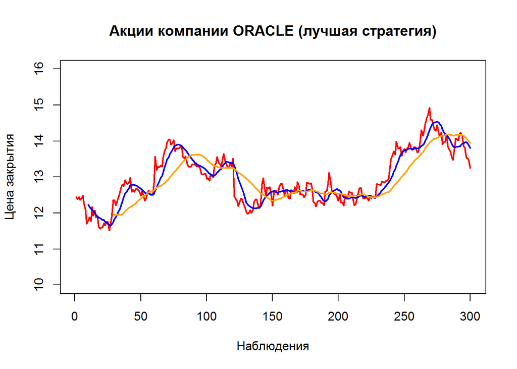

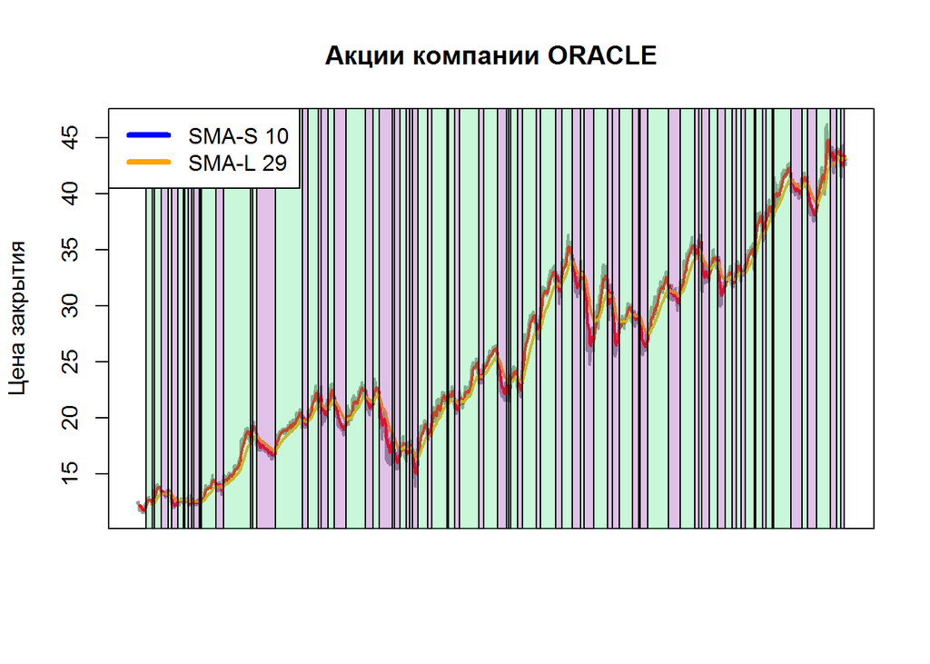